# Numerical Methods for PDEs (Spring 2017), Lab 5

Richard Southwell, Gustav Delius

# Backward difference method

As in lab 3 on the forward difference method, consider again the heat equation
$$u_{t}(x,t) = K u_{xx}(x,t), \quad 0<x< L, \quad 0<t<T,$$
subject to the boundary conditions
$$u(0, t) = u(L, t)=0,$$
and initial condition $u(x,t) = u_0(x)$.

Here $K > 0$ is the diffusion parameter. Let $N$ and $M$ be integers and let $h=L/N$ and $\tau=T/M$. Then we define the grid points $(x_k, t_j)$, where $x_k=hk$ for $k=0,1,\dots,N$ and $t_j=\tau j$ for $j=0,1,\dots,M$. The problem is to find numbers $w_{kj}$ such that $w_{kj}$ approximates the value of the exact solution $u(x,t)$ at the grid point $(x_k, t_j)$.

The backward-difference method to obtain a numerical approximation to the above problem involves solving the matrix equation:
$${\bf w}^{(j-1)}=A{\bf w}^{(j)}$$
to find ${\bf w}^{(j)}$ given ${\bf w}^{(j-1)}$ for each $j=1,2,..,M$. Here
$$A=\left[
\begin{array}{cccccc}
1+2\gamma &-\gamma &0 &\dots &\dots &0 \\
-\gamma &1+2\gamma &-\gamma &\ddots & &\vdots \\
0 &-\gamma &1+2\gamma &-\gamma &\ddots &\vdots \\
\vdots &\ddots &\ddots &\ddots &\ddots &0 \\
\vdots & &\ddots &\ddots &\ddots &-\gamma \\
0 &\dots &\dots &0 &-\gamma &1+2\gamma
\end{array}\right], \quad
{\bf w}^{(j)}
=\left[\begin{array}{c}
w_{1,j} \\ w_{2,j} \\ \vdots \\ \vdots \\ \vdots \\ w_{N-1,j}
\end{array}\right]$$
and $\gamma = \frac{K \tau }{h^2}$.

Let us choose parameters $K=1$, $L=1$, $T=0.1$, initial condition
$$u_0(x) = 2\sin(2\pi x)$$
and let us use 30 steps in both $x$ and $t$ direction. Thus we specify the grid points, time steps, and system parameters as follows:

```r
N <- 30  # Number of time points after initial state
L <- 1
h <- L/N
x <- h*(1:(N-1))  # Vector of non-boundary grid points
w <- 2*sin(2*pi*x)  # Initial condition
M <- 30  # Number of time points after initial state
T <- 0.1  # Final time
tau <- T/M  # Time step size
t <- tau*(0:M)  # Vector of time steps
K <- 1  # Diffusion rate
```

The matrix $A$ is specified by the code

```r
gamma <- K*tau/(h^2)
A <- diag(1 + 2*gamma, N-1)
for (k in 1:(N-2)){
    A[k,k+1] <- -gamma
    A[k+1,k] <- -gamma
}
```

To determine ${\bf w}^{(j)}$ from ${\bf w}^{(j-1)}$ we must solve the matrix equation ${\bf w}^{(j-1)}=A{\bf w}^{(j)}$. Later we shall discuss how to solve this equation via the double sweep method, but for simplicity we shall begin by using the R command `solve()` to calculate the matrix inverse $A^{-1}$ and then assign it to the variable `Ainv`.

```r
Ainv <- solve(A)
```

In order to evolve our system under the backwards method we repeatedly multiply our `w` object by `Ainv` inside a do loop. Thus the only difference to the forward-difference method is that we are using a different matrix, and we can use the same code as in lab 3.

```r
Temperature <- matrix(0, N-1, M+1) # Matrix to hold the solution
Temperature[ , 1] <- w
# Loop over time steps
for (j in 0:M) {
    w <- Ainv %*% w
    Temperature[ , j+1] <- w
}
```

Let’s make a 3D plot of the solution.

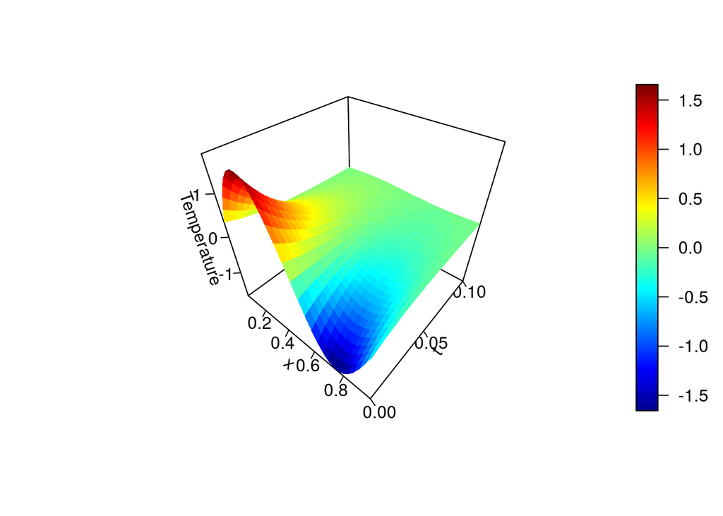

```r
library("plot3Drgl")
persp3D(x, t, Temperature,
        xlab="x", ylab="t", zlab="Temperature", # Provides axis labels
        ticktype="detailed", nticks=4) # Provides axis ticks
```

This looks just like the solution we obtained by the forward-difference method in lab 3, but notice that we now got away with using only 30 time steps, whereasfor the forward-difference method we needed much smaller time steps in order for the method to be stable.

We can now collect all the code into a function for solving the heat equation with arbitrary initial condition $u(x,0)=u_0(x)$ for $x\in[0,L]$ and $t\in [0,T]$ with the backward difference method with $N$ steps in the $x$ direction and $M$ steps in the $t$ direction

```r
backwardDifference <- function(u0=function(x) 2*sin(2*pi*x),
                              K=1, L=1, N=30, T=0.1, M=30) {
    # set up space grid
    h <- L/N
    x <- h*(1:(N-1))

    # set up time grid
    tau <- T/M
    t <- tau*(0:M)

    # set up vectors with initial condition
    w <- u0(x)

    # Set up evolution matrix
    gamma <- K*tau/(h^2)
    A <- diag(1+2*gamma, N-1)
    for (k in 1:(N-2)) {
        A[k,k+1] <- -gamma
        A[k+1,k] <- -gamma
    }
    Ainv <- solve(A)

    Temperature <- matrix(0, N-1, M+1)  # Matrix to hold the solution
    Temperature[ , 1] <- w  # Initial value
    # Loop over time steps
    for (j in 1:M) {
        w <- Ainv %*% w
        Temperature[ , j+1] <- w
    }

    # Return a list consisting of time grid, x grid and solution
    return(list(x=x, t=t, w=Temperature))
}
```

You notice that the code is very similar to the code for the function `forwardDifference()` from lab 4.

## Exercise 1

Solve the initial value from the start of this lab with the same time step size $\tau=1/300$ but with a smaller space step size of $h=1/500$.

# Double-sweep algorithm

In the code above we solved the matrix equation via matrix inversion. Now we shall consider how to tackle the problem using the double-sweep algorithm.

This algorithm can be used to determine the values $v_i$ that satisfy the tridiagonal system
$$A_{i}v_{i-1}-C_{i}v_{i}+B_{i}v_{i+1}=F_{i} \quad \hbox{for}\quad i=1, \dots, N-1;
\quad v_{0}=a, v_{N}=b;$$

In order to work we require that the coefficients $A_{i}$, $B_{i}$ and $C_{i}$ satisfy the conditions
$$A_{i}, B_{i}, C_{i} > 0, \quad C_{i} \geq A_{i} + B_{i}.$$

The first sweep of our algorithm involves determining values $\alpha_{i}$ and $\beta_{i}$ for $i=1, 2, \dots, N.$ In our algorithm we let $\alpha _1 = 0,$ $\beta_1 = a,$ and we let
$$\alpha_{i+1}=\frac{B_{i}}{C_{i}-\alpha_{i}A_{i}},$$
$$\beta_{i+1}=\frac{\beta_{i}A_{i}-F_{i}}{C_{i}-\alpha_{i}A_{i}},$$
for $i=1, \dots, N-1.$

The second sweep involves determining the values $v_i$ using the fact $v_N=b$ and the relation
$$v_{i-1}=\alpha_{i}v_{i}+\beta_{i} \quad \hbox{for} \quad
i=1, 2, \dots, N.$$

The following R function implements the double sweep algorithm:

```r
doublesweep <- function(A, B, C, F, a, b) {
    # Solves the equation
    # A[i]*v[i-1] - C[i]*v[i] + B[i]*v[i+1] = F[i]
    # for v[i], i = 1,...,N-1, with boundary conditions
    # v[0]=a and v[N]=b

    # Check the lengths of the vectors
    N <- length(C) + 1
    if ((length(B) != N-1) || (length(A) != N-1) || (length(F) != N-1)) {
        stop("The lengths of the vector arguments need to be equal")
    }

    alpha <- rep(0, N)
    beta <- rep(0, N)
    beta[1] <- a

    #sweep up to get alphas and betas
    for (i in 1:(N-1)) {
        alpha[i+1] <- B[i] / (C[i]-alpha[i]*A[i])
        beta[i+1] <- (beta[i]*A[i] - F[i]) / (C[i] - alpha[i]*A[i])
    }

    v <- rep(0, N-1 )
    v[N-1] <- alpha[N]*b + beta[N]

    #sweep down to find v's
    for (i in (N-1):2) {
        v[i-1] <- alpha[i]*v[i] + beta[i]
    }

    return(v)
}
```

Make sure you understand the details of how this code works and check that it returns values
$$\left[\begin{array}{c}
v_{1} \\ v_{2} \\ \vdots \\ \vdots \\ \vdots \\ v_{N-1}
\end{array}\right]$$
that satisfy the matrix equation
$$\left[\begin{array}{cccccc}
-C_1 &B_1 &0 &\dots &\dots &0 \\
A_2 &-C_2 &B_2 &\ddots & &\vdots \\
0 &A_3 &-C_3 &B_3 &\ddots &\vdots \\
\vdots &\ddots &\ddots &\ddots &\ddots &0 \\
\vdots & &\ddots &\ddots &\ddots &B_{N-2} \\
0 &\dots &\dots &0 &A_{N-1} &-C_{N-1}
\end{array}\right]
\left[\begin{array}{c}
v_{1} \\ v_{2} \\ v_3 \\ \vdots \\ \vdots \\ v_{N-2} \\ v_{N-1}
\end{array}\right]
=\left[\begin{array}{c}
F_{1} -aA_1 \\ F_{2} \\ F_3 \\ \vdots \\ \vdots \\ F_{N-2} \\ F_{N-1}-bB_{N-1}
\end{array}\right].$$

## Exercise 2

Use the double sweep method to solve the equation
$$\left(\begin{array}{cccc}
-1 & 2 & 0 & 0\\
2 & -1 & 1 & 0\\
0 & 3 & -1 & 4\\
0 & 0 & 1 & -7
\end{array}\right)
\left(\begin{array}{c} x_{1} \\ x_{2} \\ x_{3} \\ x_{4} \end{array}\right)
=\left(\begin{array}{c} 1 \\ 2 \\ 6 \\ -6 \end{array}\right)$$

## Exercise 3

Modify the code of the function `backwardDifference()` so that it uses the double-sweep algorithm rather than matrix inversion. Then test that the new function still gives the same result as the old function, up to rounding errors.

# Errors in backward difference method

In lab 4 you observed that in the forward-difference method the error in the numerical solution go down as the square of the stepsize in $x$. However that was only because we also decreased the step size in time with the square of the stepsize in $x$ which was required for stability. Now with the backward difference method we no longer have a constraint on the step size in time.

Let us write a function that calculates the error given the number $N$ of space steps and the number $M$ of time steps.

```r
maxError <- function(N, M) {
    # numerical solution
    numSol <- backwardDifference(M=M, N=N)
    # exact solution
    x <- numSol$x
    t <- numSol$t
    xy <- mesh(x, t)
    u <- with(xy, 2*sin(2*pi*x)*exp(-4*pi^2*y))

    return(max(abs(u - numSol$w)))
}
```

```r
maxError(30, 30)
```

```
[1] 0.04819701
```

## Exercise 4

Explore how the error depends on M and N and compare that to your theoretical expectation.